# Ngiam and Lee (2026) - memoryReproduction

William XQ Ngiam

2026-11-08

## Overview

This file is associated with the preprint titled [“Model-based evidence for task-dependent representations in psychological similarity and working memory”](https://osf.io/preprints/psyarxiv/fm9vz_v3) by William XQ Ngiam (Adelaide University) and Michael D Lee (University of California Irvine). This research project models the cognitive representation underlying perceptual tasks, working memory tasks, and similarity judgment tasks.

The following model recovers the underlying psychological space for the orientation **memory reproduction** task in [Tomic and Bays (2024)](https://psycnet.apa.org/doi/10.1037/xlm0001172). In this task, either three or six oriented lines (randomly sampled from 0 to 180 degrees) is shown to the subject. The subject is probed to recall the orientation of one of the shown lines, and has to reproduce the orientation as closely as possible.

The following code builds a Bayesian Thurstonian model using JAGS, recovering the latent representation of the orientations. This memory model **includes swap errors** - that the subject may erroneously reproduce the orientation of a non-target item in the array. A memory model that does not include swap errors is included in the original manuscript; this code can be easily adjusted to run that model.

### Requirements

The following files should be saved in your working directory:

- The data file (“oriWMData_clean.csv”) - [downloadable here](https://github.com/WilliamNgiam/orientationModeling/blob/main/data/oriWMData_clean.csv).
- The model text file (“memoryReproduction_jags.txt”) - [downloadable here](https://github.com/WilliamNgiam/orientationModeling/blob/main/memoryReproduction/memoryReproduction_jags.txt).

You will also need to have installed JAGS on your device. The installer can be accessed here: [https://sourceforge.net/projects/mcmc-jags/files/]. The following code was built using JAGS 4.3.2.

### Setup

```r
# Load required packages
library(R2jags)    # v0.8-9
library(runjags)   # parallel JAGS execution
library(tidyverse) # v2.0.0
library(coda)      # v0.19-4.1
library(ggmcmc)    # v1.5.1.2
library(here)
library(parallel)

# Provide R session output
```

[output not shown]

```r
# Set RNG seed for reproducibility
set.seed(42)

# Remove hashes from output
knitr::opts_chunk$set(comment = NA)
```

### Load data

```r
# Load in Tomic and Bays (2024) dataset
memData <- read_csv(here("oriWMData_clean.csv"), show_col_types = FALSE)

# Create 72 orientation bins on [-pi/2, pi/2) to match the perceptual task
binIntervals <- seq(-pi/2, pi/2, length.out = 73)
muTruth <- binIntervals[-73] + pi/2 # Physical bin locations on [0, pi)
sigmaTruth <- 0.01

# Fast vectorized helper to map orientations in [-pi/2, pi/2] to bin indices 1..72
angle_to_bin <- function(x) {
  idx <- max.col(-abs(outer(x, binIntervals, "-")), ties.method = "first")
  ifelse(idx == 73L, 1L, idx)
}

# Convert target and response from [-pi, pi] to [-pi/2, pi/2]
target_half <- memData$target / 2
response_half <- signif(memData$response / 2, digits = 5)

# Extract non-target orientations (already in [-pi/2, pi/2]; NaN for set size 3 slots 3..5)
nt_mat <- as.matrix(memData[, c("nontarget_1", "nontarget_2", "nontarget_3", "nontarget_4", "nontarget_5")])
nt_mat[is.nan(nt_mat)] <- NA_real_

# Assign data dimensions and vectors
nTrials <- nrow(memData)
nStimuli <- length(muTruth)
setSize <- as.integer(memData$setsize / 3)
maxPresented <- as.integer(max(memData$setsize))

# Map target and non-targets to bin indices in 1:72 (unused non-target slots fixed to 1L)
target_idx <- angle_to_bin(target_half)
nt_idx <- matrix(1L, nrow = nTrials, ncol = 5)
for (j in 1:5) {
  valid <- !is.na(nt_mat[, j])
  nt_idx[valid, j] <- angle_to_bin(nt_mat[valid, j])
}

# Build stimulus index matrix s and order non-targets by circular similarity to target
s <- cbind(target_idx, nt_idx)
target_pi <- target_half + pi/2
nt_pi <- nt_mat + pi/2

for (t in seq_len(nTrials)) {
  k <- memData$setsize[t] - 1L
  vals <- nt_pi[t, seq_len(k)]
  circ_dist <- pmin(abs(target_pi[t] - vals), pi - abs(target_pi[t] - vals))
  ord <- order(c(0, circ_dist))
  s[t, seq_len(k + 1L)] <- s[t, ord]
}
storage.mode(s) <- "integer"

# Responses on [0, pi]
y <- as.numeric(response_half + pi/2)
```

### Read in data and initial values for JAGS

```r
data.jags <- list(
  setSize = setSize,
  maxPresented = maxPresented,
  s = s,
  y = y,
  nTrials = nTrials,
  nStimuli = nStimuli
)

# Monitor only the continuous structural parameters (exclude trial-level xi and yP)
bayes.mod.params <- c("mu", "sigma", "omega3", "omega6")

# Uniform initialization of sigma on (0, pi), matching the original memoryReproduction model
bayes.mod.inits <- function(chain = 1) {
  pi_jags <- 3.1415
  list(
    sigma = runif(2, 0.2, 0.9),
    .RNG.name = "base::Mersenne-Twister",
    .RNG.seed = 100L + as.integer(chain)
  )
}
```

### Run model fit

```r
# Optimized MCMC settings:
# - 8 chains run in parallel across CPU cores
# - 2,000 adaptation + 5,000 burn-in iterations (7,000 total pre-sampling updates/chain)
# - 1,250 kept samples/chain with thin = 10 (12,500 post-burn-in updates/chain -> 10,000 total joint posterior draws)
n_chains  <- 8
n_adapt   <- 2000
n_burnin  <- 5000
n_samples <- 1250
n_thin    <- 10

inits_list <- lapply(seq_len(n_chains), bayes.mod.inits)

bayes.mod.fit <- run.jags(
  model = here("memoryReproduction_jags.txt"),
  data = data.jags,
  inits = inits_list,
  monitor = bayes.mod.params,
  n.chains = n_chains,
  adapt = n_adapt,
  burnin = n_burnin,
  sample = n_samples,
  thin = n_thin,
  method = "parallel",
  n.sims = min(n_chains, parallel::detectCores()),
  summarise = FALSE
)
```

```
Calling 8 simulations using the parallel method...
Following the progress of chain 1 (the program will wait for all chains
to finish before continuing):
Welcome to JAGS 4.3.2 (official binary) on Sun Nov  8 17:28:42 2026
JAGS is free software and comes with ABSOLUTELY NO WARRANTY
Loading module: basemod: ok
Loading module: bugs: ok
. . Reading data file data.txt
. Compiling data graph
   Initializing
   Reading data back into data table
. Reading parameter file inits1.txt
. Initializing model
. Adapting 2000
-------------------------------------------------| 2000
++++++++++++++++++++++++++++++++++++++++++++++++++ 100%
Adaptation successful
. Updating 5000
-------------------------------------------------| 5000
************************************************** 100%
. . . . . Updating 12500
-------------------------------------------------| 12500
************************************************** 100%
. . . . Updating 0
. Deleting model
All chains have finished
Simulation complete.  Reading coda files...
Coda files loaded successfully
Finished running the simulation
```

### Post-process chains and evaluate convergence

```r
# Convert to coda mcmc.list and drop deterministic +/-pi wrap copies mu[73:216]
raw_mcmc <- as.mcmc.list(bayes.mod.fit)
keep_cols <- !grepl("^mu\\[([7-9][3-9]|[8-9][0-9]|[1-9][0-9]{2})\\]$", varnames(raw_mcmc))
bayes.mod.fit.mcmc <- raw_mcmc[, keep_cols]

# Align any 0/pi boundary-wrapped mu_j chains to the nearest wrap relative to muTruth[j]
pi_jags <- 3.1415
circular_mean_half <- function(vals, pi_val = pi_jags) {
  phi <- 2 * vals
  phi0 <- atan2(mean(sin(phi)), mean(cos(phi)))
  (phi0 / 2) %% pi_val
}

for (j in 2:nStimuli) {
  param_name <- paste0("mu[", j, "]")
  for (c_idx in seq_len(n_chains)) {
    vals <- bayes.mod.fit.mcmc[[c_idx]][, param_name]
    m <- circular_mean_half(vals, pi_jags)
    cands <- c(m, m - pi_jags, m + pi_jags)
    k <- which.min(abs(cands - muTruth[j]))
    if (k != 1L) {
      bayes.mod.fit.mcmc[[c_idx]][, param_name] <- vals + (cands[k] - m)
    }
  }
}

# Convergence diagnostics across all 8 chains (Gelman-Rubin Rhat and Effective Sample Size)
stoch_cols <- setdiff(varnames(bayes.mod.fit.mcmc), "mu[1]")
rhat_vals <- gelman.diag(bayes.mod.fit.mcmc[, stoch_cols], autoburnin = FALSE, multivariate = FALSE)$psrf[, "Point est."]
ess_vals <- effectiveSize(bayes.mod.fit.mcmc[, stoch_cols])

cat(sprintf(
  "Convergence summary (%d chains, %d total draws):\n  Max Rhat = %.4f (%s)\n  Min ESS  = %.0f (%s)\n",
  n_chains, n_chains * n_samples,
  max(rhat_vals, na.rm = TRUE), names(which.max(rhat_vals)),
  min(ess_vals, na.rm = TRUE), names(which.min(ess_vals))
))
```

```
Convergence summary (8 chains, 10000 total draws):
  Max Rhat = 1.0400 (omega6[2])
  Min ESS  = 240 (omega6[2])
```

```r
summary(bayes.mod.fit.mcmc[, c("sigma[1]", "sigma[2]",
                               paste0("omega3[", 1:3, "]"),
                               paste0("omega6[", 1:6, "]"))])
```

```
Iterations = 7001:19491
Thinning interval = 10
Number of chains = 8
Sample size per chain = 1250

1. Empirical mean and standard deviation for each variable,
   plus standard error of the mean:

             Mean       SD  Naive SE Time-series SE
sigma[1]  0.30250 0.003776 3.776e-05      3.844e-05
sigma[2]  0.36620 0.007271 7.271e-05      1.151e-04
omega3[1] 0.84245 0.008000 8.000e-05      1.334e-04
omega3[2] 0.07774 0.007478 7.478e-05      1.526e-04
omega3[3] 0.07980 0.004879 4.879e-05      6.584e-05
omega6[1] 0.50827 0.018228 1.823e-04      8.515e-04
omega6[2] 0.07334 0.016979 1.698e-04      1.191e-03
omega6[3] 0.10458 0.012087 1.209e-04      4.613e-04
omega6[4] 0.07306 0.009628 9.628e-05      4.126e-04
omega6[5] 0.06914 0.009478 9.478e-05      3.966e-04
omega6[6] 0.17162 0.008873 8.873e-05      2.448e-04

2. Quantiles for each variable:

             2.5%     25%     50%     75%   97.5%
sigma[1]  0.29526 0.29989 0.30244 0.30506 0.30994
sigma[2]  0.35222 0.36123 0.36613 0.37090 0.38068
omega3[1] 0.82659 0.83701 0.84253 0.84793 0.85758
omega3[2] 0.06353 0.07268 0.07761 0.08264 0.09297
omega3[3] 0.07039 0.07640 0.07977 0.08314 0.08953
omega6[1] 0.47320 0.49599 0.50835 0.52040 0.54411
omega6[2] 0.04094 0.06189 0.07309 0.08492 0.10645
omega6[3] 0.08091 0.09658 0.10447 0.11268 0.12910
omega6[4] 0.05438 0.06650 0.07283 0.07950 0.09239
omega6[5] 0.05013 0.06298 0.06918 0.07560 0.08762
omega6[6] 0.15469 0.16553 0.17155 0.17739 0.18953
```

### Plots

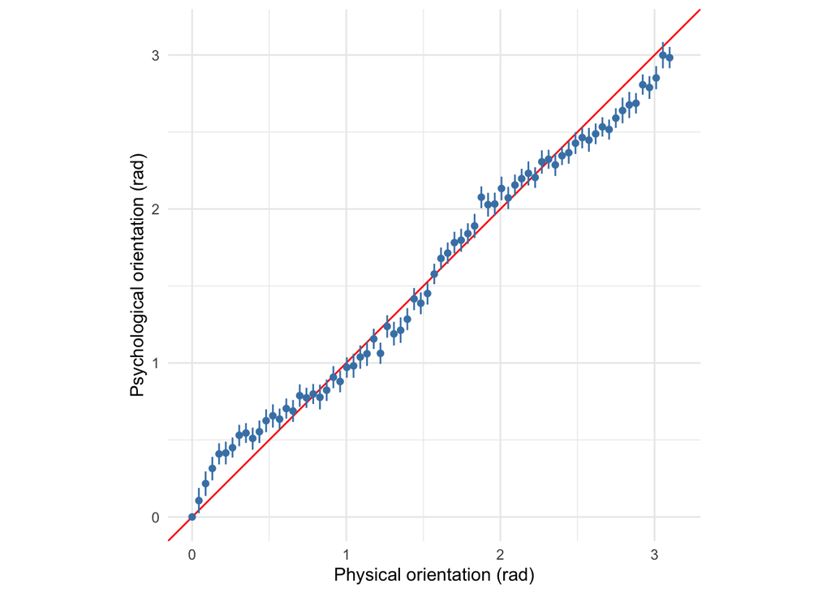

```r
# Convert into ggmcmc object using all converged chains
bayes.mod.fit.gg <- ggs(bayes.mod.fit.mcmc)

# Summarize each mu[1:72] across all chains on the half-circle [0, pi)
summarize_half_circle <- function(vals, ci = c(0.025, 0.975), pi_val = pi) {
  phi <- (2 * vals) %% (2 * pi_val)
  phi0 <- atan2(mean(sin(phi)), mean(cos(phi)))
  if (phi0 < 0) phi0 <- phi0 + 2 * pi_val
  rel <- Arg(exp(1i * (phi - phi0)))
  rel_bounds <- quantile(rel, probs = ci, names = FALSE)
  mu_mean <- (phi0 / 2) %% pi_val
  list(
    mean = mu_mean,
    low  = (mu_mean + rel_bounds[1] / 2) %% pi_val,
    high = (mu_mean + rel_bounds[2] / 2) %% pi_val
  )
}

mu_mat <- do.call(rbind, bayes.mod.fit.mcmc)[, paste0("mu[", 1:nStimuli, "]")]
mu_summary <- map_dfr(seq_len(nStimuli), function(j) {
  res <- summarize_half_circle(mu_mat[, j])
  tibble(
    idx = j,
    Parameter = factor(paste0("mu[", j, "]"), levels = paste0("mu[", seq_len(nStimuli), "]")),
    physical = muTruth[j],
    median = res$mean,
    low = res$low,
    high = res$high
  )
})

# Split intervals that wrap across the pi/0 boundary (low > high) into two segments: [0, high] and [low, pi]
mu_segments <- bind_rows(
  mu_summary %>%
    filter(low <= high) %>%
    transmute(idx, Parameter, physical, y_start = low, y_end = high),
  mu_summary %>%
    filter(low > high) %>%
    transmute(idx, Parameter, physical, y_start = 0, y_end = high),
  mu_summary %>%
    filter(low > high) %>%
    transmute(idx, Parameter, physical, y_start = low, y_end = pi)
)

ggplot() +
  geom_abline(slope = 1, intercept = 0, colour = "red", linewidth = 0.5) +
  geom_segment(data = mu_segments,
               mapping = aes(x = physical,
                             xend = physical,
                             y = y_start,
                             yend = y_end),
               colour = "steelblue") +
  geom_point(data = mu_summary,
             mapping = aes(x = physical,
                           y = median),
             colour = "steelblue",
             size = 1.5) +
  coord_fixed(xlim = c(0, pi), ylim = c(0, pi)) +
  labs(x = "Physical orientation (rad)", y = "Psychological orientation (rad)") +
  theme_minimal()
```

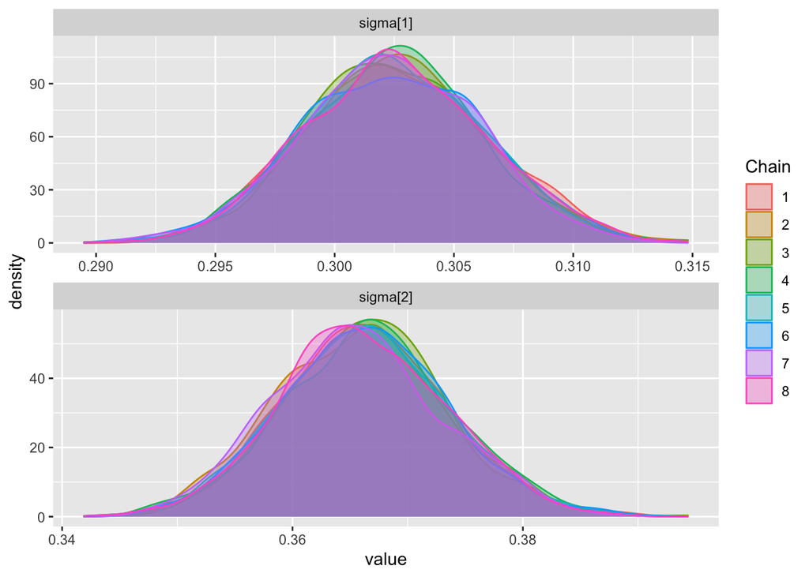

```r
ggs_density(bayes.mod.fit.gg,
            family = "sigma")
```

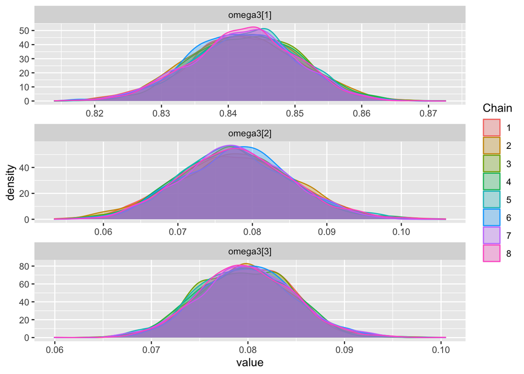

```r
ggs_density(bayes.mod.fit.gg,
            family = "omega3")
```

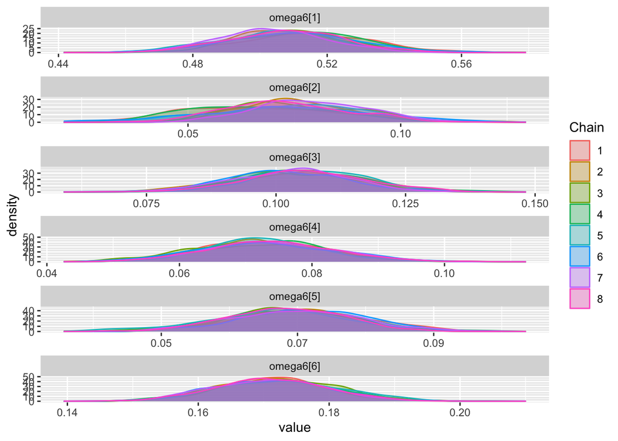

```r
ggs_density(bayes.mod.fit.gg,
            family = "omega6")
```